# Coursework 2 for Cardiac MR Image Segmentation (2020-2021)

After you have gone through the coursework description, this tutorial is designed to further helps you understand the problem and therefore enable you to propose a good solution for this coursework. You will learn:

- how to load and save images with OpenCV
- how to train a segmentation model with Pytorch
- how to evaluate the trained model

# Introduction:

In this report we are going to perform semantic image segmentation on the Automatic Cardiac Diagnosis Challenge” dataset (ACDC), the largest publicly-available and fully-annotated dataset for the purpose of Cardiac MRI (CMR) assessment. The dataset has been modified for our purpose and is now composed of a total of 200 Cardiovascular Magnetic Resonance (CMR) given in a PNG format. The dataset is then split into 50% for the training, 10% for the validation and 40% for the testing. When we overlay a single channel of our target (or prediction), we refer to this as a mask which illuminates the regions of an image where a specific class is present.

[1]

# The machine learning task:

Semantic image segmentation of magnetic resonance images is the process of taking either a RGB color image (height x width x 3) or a grayscale image (height x width x 1) and outputting a segmentation map where each pixel contains a class label represented as integer. The purpose is to see how accurately our method can segment these CMR images in the test set, by comparing the segmentation masks with the ground truth masks we hold. The core part of the process is constructing a neural network architecture that stacks a number of convolutional layers to learn a mapping from the input image to its corresponding segmentation through the successive transformation of feature mappings to make predictions all at once. Preserving the full resolution throughout the network is computationally expensive and so there are several approaches to retrieve the same image size saving computational cost. Our approach is explained in the implementation sections.

# Relevant work and what we aimed to achieve.

In order to understand where to begin with this task we looked at previous examples and academic articles that discussed the process of semantic segmentation, particularly medical semantic segmentation. This formed the basis of our decision regarding architecture and approach. The U-Net architecture is a popular architecture for application in medical imaging and is used widely with success.Based on the popularity of this model and the appropriate usage of the application we decided to implement the U-Net model for this task.

## 1. Load, show, and save images with OpenCV

OpenCV is an open-source computer vision library which helps us to manipulate image data. In this section, we will cover:

- Loading an image from file with imread()
- Displaying the image with matplotlib plt.imshow()
- Saving an image with imwrite()

For a more comprehensive study of OpenCV, we encourage you to check the official [OpenCV documentation](https://docs.opencv.org/master/index.html).

```python
from matplotlib import pyplot as plt
import numpy as np
def show_image_mask(img, mask, cmap='gray'): # visualisation
    fig = plt.figure(figsize=(5,5))
    plt.subplot(1, 2, 1)
    plt.imshow(img, cmap=cmap)
    plt.axis('off')
    plt.subplot(1, 2, 2)
    plt.imshow(mask, cmap=cmap)
    plt.axis('off')
```

```
(96, 96)
```

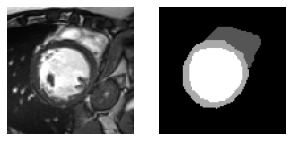

```
True
```

```python
import os
import cv2 #import OpenCV
from google.colab import drive
drive.mount('/content/drive')
data_dir = '/content/drive/My Drive/Neural Computation/data/train'

image = cv2.imread(os.path.join(data_dir,'image','cmr1.png'), cv2.IMREAD_UNCHANGED)
mask = cv2.imread(os.path.join(data_dir,'mask','cmr1_mask.png'), cv2.IMREAD_UNCHANGED)
print(mask.shape)
show_image_mask(image, mask, cmap='gray')
plt.pause(1)
cv2.imwrite(os.path.join('./','cmr1.png'), mask*85)
```

Note: You will no doubt notice that the mask images appear to be completely black with no sign of any segmentations. This is because the max intensity of pixels in an 8-bit png image is 255 and your image viewer software only sees 255 as white. For those values close to zero, you will only see dark values. This is the case for our masks as the background, the right ventricle, the myocardium, and the left ventricle in each image are 0, 1, 2, and 3, respectively. All of which are close to zero. If we multiply the original mask by 85 and save the result to the directory where this code is, we can see the heart indeed shows up.

## 2 Define a segmentation model with Pytorch

In this section, we expect you to learn how to:

- Define a Segmentation Model
- Define a DataLoader that inputs images to the Model
- Define training parameters and train the model
- Test the trained model with a new input image

### 2.1 Define a DataLoader

Below we provide you with a dataloader to use in your assigment. You will only need to focus on the development of your model and loss function.

```python
import torch


device = 'cuda:0' if torch.cuda.is_available() else 'cpu'  # check whether a GPU is available

print(device)
print(torch.cuda.is_available())
y = torch.ones(3,4, device=device)  # directly create a tensor on GPU
x = torch.rand(3,4).to(device)      # or just use .to(device)
z = x+y
print(z)
```

```
cpu
False
tensor([[1.3135, 1.8186, 1.7076, 1.8036],
        [1.2107, 1.4792, 1.0725, 1.9782],
        [1.3333, 1.5591, 1.3311, 1.0089]])
```

```python
import torch
import torch.utils.data as data
import cv2
import os
from glob import glob

class TrainDataset(data.Dataset):
    def __init__(self, root=''):
        super(TrainDataset, self).__init__()
        self.img_files = glob(os.path.join(root,'image','*.png'))
        self.mask_files = []
        for img_path in self.img_files:
            basename = os.path.basename(img_path)
            self.mask_files.append(os.path.join(root,'mask',basename[:-4]+'_mask.png'))


    def __getitem__(self, index):
            img_path = self.img_files[index]
            mask_path = self.mask_files[index]
            data = cv2.imread(img_path, cv2.IMREAD_UNCHANGED)
            label = cv2.imread(mask_path, cv2.IMREAD_UNCHANGED)
            return torch.from_numpy(data).float(), torch.from_numpy(label).float()

    def __len__(self):
        return len(self.img_files)

class TestDataset(data.Dataset):
    def __init__(self, root=''):
        super(TestDataset, self).__init__()
        self.img_files = glob(os.path.join(root,'image','*.png'))

    def __getitem__(self, index):
            img_path = self.img_files[index]
            data = cv2.imread(img_path, cv2.IMREAD_UNCHANGED)
            return torch.from_numpy(data).float()

    def __len__(self):
        return len(self.img_files)
```

### 2.2 Define a Segmenatation Model

# Implementation: describe how you implemented your neural network

The U-net architecture consists of a contracting path (downsampling) to capture context, and a symmetric expansive path (upsampling) that enables precise localization, which gives it the u-shaped architecture. In this task the input tensor to the network is of size (B, 1, H, W) and the output tensor from the network is of size (B, 4, H, W). Here B denotes batch size, H and W stand for image height and width, respectively.

We chose to use the u-net convolutional network architecture because it gave fast and precise segmentation of images and it was specifically designed for medical image segmentation. Up until now it has outperformed the prior best method such as sliding-windows convolutional network. It is also strong enough to make good predictions based on even a few datasets by using excessive data augmentation techniques.

# Downsampling

The downsampling path is a typical convolutional network that consists of double convoluted input image and a repeated application of max pooling operations, each followed by double convolution with reflecting linear unit (ReLU). During the contraction, the spatial resolution of the input and so the information of it is reduced while feature information is increased. In this way, we develop a lower resolution feature mapping which is taught to be highly efficient at discriminating between classes. The max pooling operation downsamples the resolution image by summarizing a local area with a single value by taking the maximum of that area and create a new matrix that corrisponds to each max of the filtered areas.

Here is the implementation of the double convolution, each followed by a batch normalisation and ReLU.

```python
import torch
import torch.nn as nn
import torch.nn.functional as F


def double_conv(in_c, out_c, half=False):
    """
    sequential of double convolution with Relu
    :param in_c: input channels
    :param out_c: output channels
    :param half: crop to half, True for upsampling. False for downsampling
    :return: sequential of double convolution with Relu activation
    """
    cut = in_c // 2 if half else out_c
    conv = nn.Sequential(
            nn.Conv2d(in_c, cut, kernel_size=3, padding=1),
            nn.BatchNorm2d(cut),
            nn.ReLU(inplace=True),
            nn.Conv2d(cut, out_c, kernel_size=3, padding=1),
            nn.BatchNorm2d(out_c),
            nn.ReLU(inplace=True))
    return conv
```

Max pooling of stride 2 to downsize the image by half

```python
def max_pool(in_c, out_c):
    """
    performs a downsampling step using a max pooling of stride 2 and a double convolution
    :param in_c: input channels
    :param out_c: output channels
    :return: sequential of max pooling and double convolution
    """
    maxpool = nn.Sequential(
            nn.MaxPool2d(2),
            double_conv(in_c, out_c))
    return maxpool
```

# Upsampling

The upsampling pathway combines the feature and spatial information through a sequence of bilinear interpolate upsampling and double convolutions of concatenations with high-resolution features from the corrisponding steps from the contracting path. During the expansive path we make use of a linear interpolation operation that distributes a single value into a higher resolution.

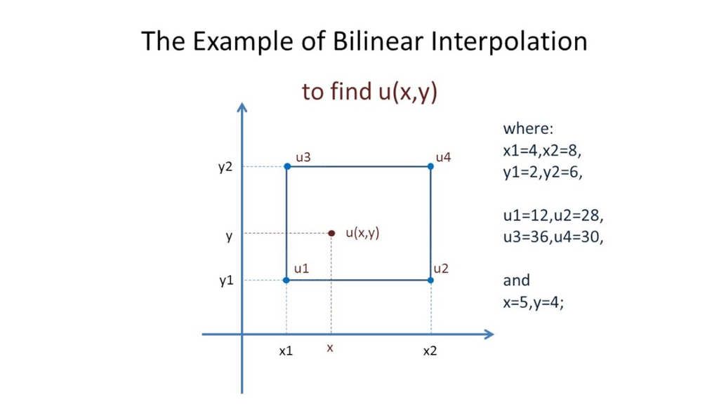

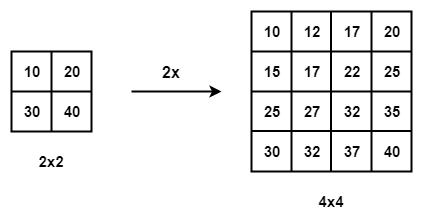

```python
class UpConv(nn.Module):
    """
    Upsampling with bilinear interpolation followed by double convolution
    """
    def __init__(self, in_c, out_c):
        super().__init__()
        self.up = nn.Upsample(scale_factor=2, mode='bilinear', align_corners=True)
        self.conv = double_conv(in_c, out_c, True)

    def forward(self, x1, x2):
        """
        double convolution of a concatenation of x1 and x2
        :param x1: image to be upsampled
        :param x2: image to be cropped
        :return: double convoluted concatenation of x2 with x1
        """

        x1 = self.up(x1)

        delta_height = x2.size()[2] - x1.size()[2]
        delta_width = x2.size()[3] - x1.size()[3]

        # padding
        x1 = F.pad(x1, [delta_width // 2, delta_width - delta_width // 2,
                        delta_height // 2, delta_height - delta_height // 2])

        x = torch.cat([x2, x1], dim=1)
        return self.conv(x)
```

# U-Net structure:

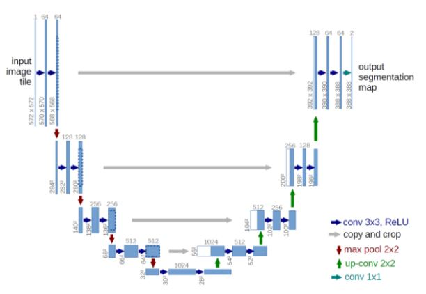

[2]

Following the suggested structure of the original paper, here we apply a double convolution to the input image and then followed by four downsampling steps, each step consists of a maxpooling and a double convolution. On the other hand, the upsampling also consists of four steps, each include bilinear interpolate unpsampling followed by a double convolution on the result of the concatentation with the corresponding step from the downsampling.

```python
class CNNSEG(nn.Module):  # Define your model
    def __init__(self):
        super(CNNSEG, self).__init__()
        self.input_double_conv = double_conv(1, 64)
        self.down_conv_1 = max_pool(64, 128)
        self.down_conv_2 = max_pool(128, 256)
        self.down_conv_3 = max_pool(256, 512)
        self.down_conv_4 = max_pool(512, 512)
        self.up_conv_1 = UpConv(1024, 256)
        self.up_conv_2 = UpConv(512, 128)
        self.up_conv_3 = UpConv(256, 64)
        self.up_conv_4 = UpConv(128, 64)
        self.single_conv_out = nn.Conv2d(64, 4, kernel_size=1)

    def forward(self, x):
        x1 = self.input_double_conv(x)
        x2 = self.down_conv_1(x1)
        x3 = self.down_conv_2(x2)
        x4 = self.down_conv_3(x3)
        x5 = self.down_conv_4(x4)
        x = self.up_conv_1(x5, x4)
        x = self.up_conv_2(x, x3)
        x = self.up_conv_3(x, x2)
        x = self.up_conv_4(x, x1)
        return self.single_conv_out(x)

model = CNNSEG()
model = model.to(device)
```

### 2.3 Define a Loss function and optimizer

You will need to define a loss function and an optimizer. torch.nn has a variety of readymade loss functions, although you may wish to create your own instead. torch.optim has a variety of optimizers, it is advised that you use one of these.

```python
epochs = 30

Loss = nn.CrossEntropyLoss()
optimizer = torch.optim.Adam(model.parameters(), lr=0.001, betas=(0.9, 0.999), eps=1e-08, weight_decay=0, amsgrad=False)
```

### 2.4 Training

As most of you will use CPUs to train the model, expect your models to take **30 minutes to train if not longer depending on network architecture**. To save time, you should not be using all training data until your model is well developed. If you are running your model on a GPU training should be significantly faster. During the training process, you may want to save the checkpoints as follows:

```
# Saving checkpoints for validation/testing
torch.save(model.state_dict(), path)
```

The saved checkpoints can be used to load at a later date for validation and testing. Here we give some example code for training a model. Note that you need to specify the max iterations you want to train the model.

```python
from torch.utils.data import DataLoader
from PIL import Image
data_path = '/content/drive/My Drive/Neural Computation/data/train'
num_workers = 4
batch_size = 4
train_set = TrainDataset(data_path)
training_data_loader = DataLoader(dataset=train_set, num_workers=num_workers, batch_size=batch_size, shuffle=True)

min_loss = float('inf')

saved_model_path = '/content/drive/My Drive/Neural Computation/validation/testing/model.sav'
model.train()


losses = []
train_loss = []
train_accu = []

for epoch in range(epochs):

    batch_loss = 0.0

    # Fetch images and labels.
    for iteration, sample in enumerate(training_data_loader):
        epoch_loss= []
        img, mask = sample
        print("Epochs " + str(epoch + 1), "Iteration " + str(iteration + 1))
        model.to(device)
        img = img[:, None, :, :]

        out = model.forward(img.to(device))
        print("forward done")

        optimizer.zero_grad()
        forward = model.forward(img.to(device))



        pred = model(img.to(device))
        loss = Loss(pred.to(device), mask.long().to(device))

        print('Loss: ', loss.item(), " minimum: ", min_loss)
        if loss.item() < min_loss:
            min_loss = loss.item()
            torch.save(model.state_dict(), saved_model_path)

        loss.backward()
        train_loss.append(loss.item())
        prediction = pred.data.max(1)[1]
        accuracy = prediction.eq(mask.to(device)).sum()/(batch_size*100.)
        print('Accuracy: {:.3f}'.format(accuracy))

        train_accu.append(accuracy)
        if loss.item() > batch_loss:
            batch_loss = loss.item()
        optimizer.step()
        acc = accuracy/100.00
        print(acc)

    losses.append(batch_loss)
```

```
Epochs 1 Iteration 1
forward done
Loss:  1.4961308240890503  minimum:  inf
Accuracy: 17.003
tensor(0.1700)
Epochs 1 Iteration 2
forward done
Loss:  1.2897402048110962  minimum:  1.4961308240890503
Accuracy: 49.147
tensor(0.4915)
Epochs 1 Iteration 3
forward done
Loss:  1.3313794136047363  minimum:  1.2897402048110962
Accuracy: 56.662
tensor(0.5666)
Epochs 1 Iteration 4
forward done
Loss:  1.1081712245941162  minimum:  1.2897402048110962
Accuracy: 60.835
tensor(0.6083)
Epochs 1 Iteration 5
forward done
Loss:  0.9420642852783203  minimum:  1.1081712245941162
Accuracy: 72.707
tensor(0.7271)
Epochs 1 Iteration 6
forward done
Loss:  0.8596208095550537  minimum:  0.9420642852783203
Accuracy: 77.175
tensor(0.7718)
Epochs 1 Iteration 7
forward done
Loss:  0.8243986368179321  minimum:  0.8596208095550537
Accuracy: 76.750
tensor(0.7675)
Epochs 1 Iteration 8
forward done
Loss:  0.7938668131828308  minimum:  0.8243986368179321
Accuracy: 80.200
tensor(0.8020)
```

[output cut: 687 more lines]

```
Loss:  0.10222344845533371  minimum:  0.08636479079723358
Accuracy: 89.275
tensor(0.8928)
Epochs 6 Iteration 22
forward done
Loss:  0.14727690815925598  minimum:  0.08636479079723358
Accuracy: 87.525
tensor(0.8753)
Epochs 6 Iteration 23
forward done
Loss:  0.10588804632425308  minimum:  0.08636479079723358
Accuracy: 89.330
tensor(0.8933)
Epochs 6 Iteration 24
forward done
```

```python
from matplotlib import pyplot as plt
#this shows the max loss per epoch
plt.plot(losses)
plt.xlabel("The number of epochs")
plt.ylabel("Loss")
plt.show()
#this shows the loss values about total steps
plt.xlabel("The number of steps")
plt.ylabel("Loss")
plt.plot(np.arange(len(train_loss)), train_loss)
plt.show()
plt.plot(np.arange(len(train_accu)), train_accu)
plt.xlabel("The number of steps")
plt.ylabel("Accuracy")
plt.show()
```

[output not shown]

### 2.5 Testing

When validating the trained checkpoints (models), remember to change the model status as **Evaluation Mode**

```python
import numpy as np
from torchvision import transforms
from torch.autograd import Variable
```

```python
# In this block you are expected to write code to load saved model and deploy it to all data in test set to
# produce segmentation masks in png images valued 0,1,2,3, which will be used for the submission to Kaggle.
data_path = '/content/drive/My Drive/Neural Computation/data/test'
num_workers = 4
batch_size = 4

test_set = TestDataset(data_path)
test_data_loader = DataLoader(dataset=test_set, num_workers=num_workers,batch_size=batch_size, shuffle=False)

model.eval()


for iteration, sample in enumerate(test_data_loader):
    img = sample
    #print(img.shape)
    #show_image_mask(img[0,...].squeeze(), mask[0,...].squeeze()) #visualise all data in training set


    #plt.pause(1)
    #plt.imshow(img[0,...].squeeze(), cmap='gray') #visualise all images in test set
    #plt.pause(1)
    img= img.unsqueeze(1)
    img = img.to(device)
    pred = model(img)
    print(pred.shape)
    print(img.shape)
    #pred = torch.sigmoid(pred)
    pred = torch.argmax(pred.squeeze(),dim=1)
    #plt.imshow(pred[0,...].squeeze())
    #plt.pause(1)
    print(pred.shape)
    show_image_mask(img[0,...].squeeze().cpu(), pred[0,...].cpu())
    show_image_mask(img[0,...].squeeze().cpu(), pred[1,...].cpu())
    show_image_mask(img[0,...].squeeze().cpu(), pred[2,...].cpu())
    show_image_mask(img[0,...].squeeze().cpu(), pred[3,...].cpu())
    plt.pause(1)





    #print(pred.shape)
    #im = transforms.ToPILImage()(pred[1])
    if torch.cuda.is_available():
      pred = pred.detach().cpu().numpy()
      img1 = img.detach().cpu().numpy()
    #print(pred)
    #img2 = Image.fromarray(pred, mode="RGBa")





    #plt.imsave( "./data/test/mask/cmr{}.png".format(iteration), pred[1,...].squeeze(), cmap="gray")
```

## 3 Evaluation

As we will automatically evaluate your predicted test makes on Kaggle, in this section we expect you to learn:

- what is the Dice score used on Kaggle to measure your models performance
- how to submit your predicted masks to Kaggle

### 3.1 Dice Score

To evaluate the quality of the predicted masks, the Dice score is adopted. Dice score on two masks A and B is defined as the intersection ratio between the overlap area and the average area of two masks. A higher Dice suggests a better registration.

$Dice (A, B)= \frac{2|A \cap B|}{|A| + |B|} $

However, in our coursework, we have three labels in each mask, we will compute the Dice score for each label and then average the three of them as the final score. Below we have given you `categorical_dice` for free so you can test your results before submission to Kaggle.

```python
def categorical_dice(mask1, mask2, label_class=1):
    """
    Dice score of a specified class between two volumes of label masks.
    (classes are encoded but by label class number not one-hot )
    Note: stacks of 2D slices are considered volumes.

    Args:
        mask1: N label masks, numpy array shaped (H, W, N)
        mask2: N label masks, numpy array shaped (H, W, N)
        label_class: the class over which to calculate dice scores

    Returns:
        volume_dice
    """
    mask1_pos = (mask1 == label_class).astype(np.float32)
    mask2_pos = (mask2 == label_class).astype(np.float32)
    dice = 2 * np.sum(mask1_pos * mask2_pos) / (np.sum(mask1_pos) + np.sum(mask2_pos))
    return dice
```

```python
#evalute
data_path = '/content/drive/My Drive/Neural Computation/data/val'
num_workers = 4
batch_size = 4


val_set = TrainDataset(data_path)
val_data_loader = DataLoader(dataset=train_set, num_workers=num_workers, batch_size=batch_size, shuffle=False)
model.eval()
# Fetch images and labels.


for iteration, sample in enumerate(val_data_loader):
    img,mask = sample



    img= img.unsqueeze(1)
    img = img.to(device)
    pred = model(img)
    print(pred.shape)
    print(img.shape)
    pred = torch.argmax(pred.squeeze(),dim=1)
    mask = mask.cpu().numpy()
    plt.imshow(mask[0,...].squeeze())
    plt.pause(1)

    if torch.cuda.is_available():
        pred = pred.detach().cpu().numpy()
        img = img.detach().cpu().numpy()
    else:
        pred = pred.cpu().numpy()
        img = img.cpu().numpy()

    show_image_mask(img[0,...].squeeze(), pred[0,...])
    plt.pause(1)
    show_image_mask(img[0,...].squeeze(), pred[1,...])
    plt.pause(1)
    show_image_mask(img[0,...].squeeze(), pred[2,...])
    plt.pause(1)
    show_image_mask(img[0,...].squeeze(), pred[3,...])
    plt.pause(1)

    print(categorical_dice(mask,pred,label_class = 1))
    print(categorical_dice(mask,pred,label_class = 2))
    print(categorical_dice(mask,pred,label_class = 3))
    print((categorical_dice(mask,pred,label_class = 1)+categorical_dice(mask,pred,label_class = 2)+categorical_dice(mask,pred,label_class = 3))/3)
```

### 3.2 Submission

Kaggle requires your submission to be in a specific CSV format. To help ensure your submissions are in the correct format, we have provided some helper functions to do this for you. For those interested, the png images are run-length encoded and saved in a CSV to the specifications required by our competition.

It is sufficient to use this helper function. To do so, save your 80 predicted masks into a directory. ONLY the 80 predicted masks should be in this directory. Call the submission_converter function with the first argument as the directory containing your masks, and the second the directory in which you wish to save your submission.

```python
import numpy as np
import os
import cv2

def rle_encoding(x):
    '''
    *** Credit to https://www.kaggle.com/rakhlin/fast-run-length-encoding-python ***
    x: numpy array of shape (height, width), 1 - mask, 0 - background
    Returns run length as list
    '''
    dots = np.where(x.T.flatten() == 1)[0]
    run_lengths = []
    prev = -2
    for b in dots:
        if (b > prev + 1): run_lengths.extend((b + 1, 0))
        run_lengths[-1] += 1
        prev = b
    return run_lengths


def submission_converter(mask_directory, path_to_save):
    writer = open(os.path.join(path_to_save, "submission.csv"), 'w')
    writer.write('id,encoding\n')

    files = os.listdir(mask_directory)

    for file in files:
        name = file[:-4]
        mask = cv2.imread(os.path.join(mask_directory, file), cv2.IMREAD_UNCHANGED)

        mask1 = (mask == 1)
        mask2 = (mask == 2)
        mask3 = (mask == 3)

        encoded_mask1 = rle_encoding(mask1)
        encoded_mask1 = ' '.join(str(e) for e in encoded_mask1)
        encoded_mask2 = rle_encoding(mask2)
        encoded_mask2 = ' '.join(str(e) for e in encoded_mask2)
        encoded_mask3 = rle_encoding(mask3)
        encoded_mask3 = ' '.join(str(e) for e in encoded_mask3)

        writer.write(name + '1,' + encoded_mask1 + "\n")
        writer.write(name + '2,' + encoded_mask2 + "\n")
        writer.write(name + '3,' + encoded_mask3 + "\n")

    writer.close()
```

# Experiments:

For the experiments on our model we decided to focus on loss function, optimizer and the necessary hyperparameters, epochs and batch sizes individually to see how our model would react to changes, and how the loss function, dice score and the accuracy of the mask would adapt to those changes. We then decided to investigate them simultaneously using a combination of hyperparameters to better understand which of them was more influential on the result either in a positive and negative way.

First we decided to investigate the behaviour of the loss function compared with different optimisers. Initially we decided to use the cross entropy loss function as it is the most commonly used loss function for image segmentation and it is a pixel-wise cross entropy loss. This loss examines each pixel individually, comparing the class predictions (depth-wise pixel vector) to our one-hot encoded target vector. Because of the way it works it evaluates the class predictions for each pixel vector individually and then averages over all pixels, essentially we assert equal learning to each pixel in the image.

**1. Cross Entropy Loss, SGD Optimiser**

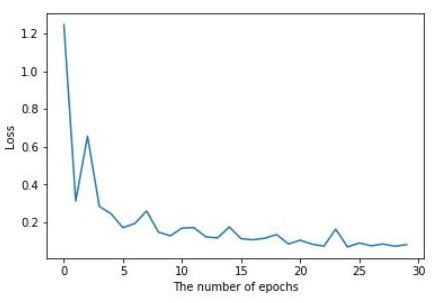

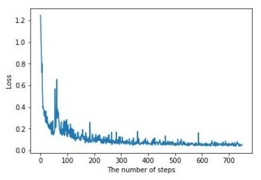

**2. Cross Entropy Loss, Adam Optimiser**

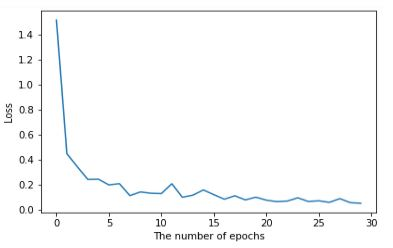

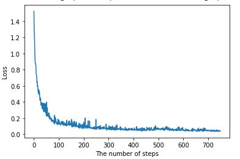

For this reason, despite the time and hardware constraints we decided to run the algorithm for longer and at 100 epochs the Loss was 0.01146851748 with a registered minimum of 0.01070599259. After 200 epochs the loss reaches incredibly low values of 0.0038105174 with a registered minimum of 0.0017915075. The model was then evaluated. Calculating the dice score showed that the predictions were pretty accurate and thus yielded an average dice score of 0.981691901773683. This is a really high dice score as it is measured between 0 and 1 and thus shows quite an accurate model. This has outperformed SGD.

**3. Cross Entropy Loss, RMSprop optimizer**

To furthermore confirm that Adam was the best optimizer we then tested the cross entropy loss function with the Root Mean Square Propagation that uses a moving average of squared gradients to normalize the gradient itself. That has an effect of balancing the step size — decrease the step for large gradients to avoid exploding, and increase the step for small gradients to avoid vanishing. It is very similar to the gradient descent algorithm with momentum. Here is the result of this experiment: Loss = nn.CrossEntropyLoss() optimizer = torch.optim.RMSprop(model.parameters(), lr=0.01, alpha=0.99, eps=1e-08, weight_decay=0, momentum=0, centered=False).

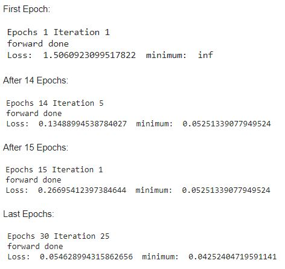

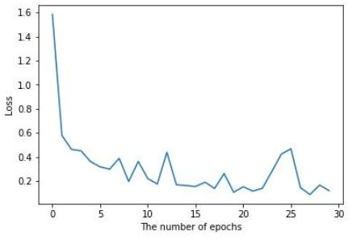

The combination of the cross entropy loss with the RMSprop optimizer shows a very high loss at the end of the first epoch and first iteration, but as we go through the epochs we notice that it takes 14 Epochs to go down to 0.052. Despite the loss immediately increasing again as we can see in Epoch 15 and then decreasing the minimum remains stable for the training and reaches a minimum of 0.042 after 30 Epochs. We reach a loss of 0.05 after 30 epochs and we are not able to reach a lower value and as expected, Adam performed better. The value of the loss that we obtain is relatively good and so the average dice score is 0.9151543585324852. We can see the comparison between the predicted mask and the ground truth is fairly accurate. However this is not the best combination of loss function and optimizer that we have seen and so we will not investigate the hyperparameters of this optimizer.

The best combination was found to be Adam optimizer with the cross entropy loss but since the results on 30 epochs was optimal both for Adam and SGD, instead of just using the default parameters we decided to tune the hyperparameters of the two optimizer to furthermore check which one performed better and retrieve the best result.

# Tuning Adam’s Hyperparameters

**The following set of the experiments were executed using the cross entropy loss function and the Adam optimizer.**

**Weight Decay:**

With the use of weight decay after each update, the weights are multiplied by a regularization factor called lambda. This prevents the weights from growing too large because large weights tend to cause sharp transitions in the node functions and thus large changes in output for small changes in the inputs. This can be seen as gradient descent on a quadratic regularization term.The most common type of regularization is L2 with values of lambda (regularization hyperparameter) often on a logarithmic scale between 0 and 0.1, such as 0.1, 0.001, 0.0001, etc.

**The first experiment involved a change only in the weight decay, from 0 to 0.1:**

Loss = nn.CrossEntropyLoss() optimizer = torch.optim.Adam(model.parameters(), lr=0.001, betas=(0.9, 0.999), eps=1e-08, weight_decay=0.1, amsgrad=False)

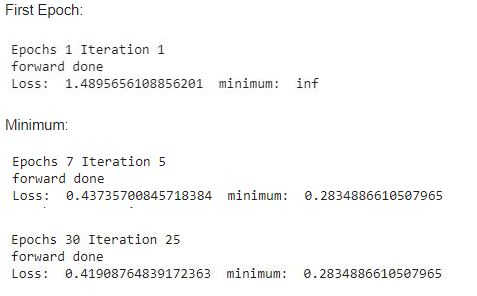

[figure not shown]

The result on the dice score is terrible, with this set of hyperparameters we completely fail the task and we do not get even closer to the prediction of the mask. Average dice score: 0.05927835051546392.

**For the second experiments we decrease the weight decay from 0.1 to 0.01:**

Loss = nn.CrossEntropyLoss() optimizer = torch.optim.Adam(model.parameters(), lr=0.001, betas=(0.9, 0.999), eps=1e-08, weight_decay=0.01, amsgrad=False)

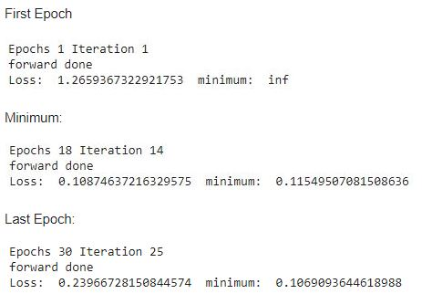

This experiment also confirmed that decreasing the weight decay to a lower value closer to zero improves the performance of the algorithm because it allows the weight to better fit the data. Loss function reached lower values through the epochs with a minimum of 0.10 around epoch 18 and Dice Score increases for the validation,despite that we are still far from reaching good performance and the results cannot be considered optimal. Average dice score: 0.6196801149823052.

**For the third experiments we furthermore decrease the weight decay from 0.01 to 0.001:**

Loss = nn.CrossEntropyLoss() optimizer = torch.optim.Adam(model.parameters(), lr=0.001, betas=(0.9, 0.999), eps=1e-08, weight_decay=0.001, amsgrad=False)

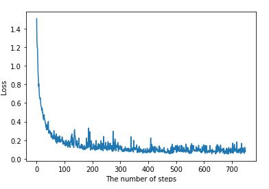

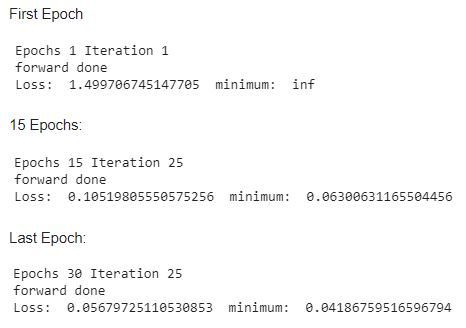

Average dice score: 0.8250789654729332.

We can then conclude that the optimal value for our weight decay is the closest possible to zero and for our purpose and with the dataset that we have we will make the weight decay equal to 0. We will just avoid training the dataset for too many epochs by applying early stopping so that we won’t incur in overfitting and poor performance on the test set.

**Learning Rate**

The learning rate is a hyperparameter that controls how much to change the model in response to the estimated error each time the model weights are updated. Choosing the learning rate is challenging as a value too small may result in a long training process that could get stuck, whereas a value too large may result in learning a sub-optimal set of weights too fast or an unstable training process

**First experiment: LR = 0.1**

Loss = nn.CrossEntropyLoss() optimizer = torch.optim.Adam(model.parameters(), lr=0.1, betas=(0.9, 0.999), eps=1e-08, weight_decay=0, amsgrad=False)

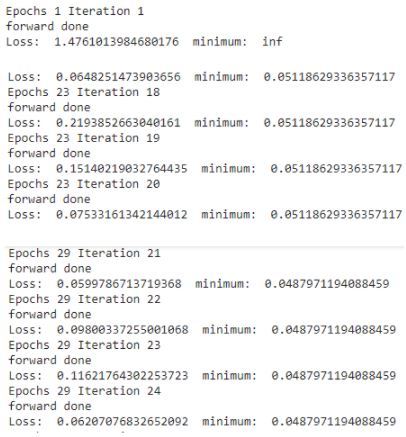

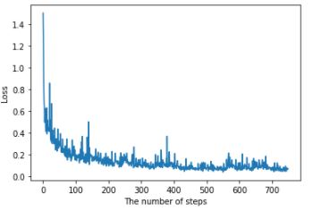

**Second experiment: LR= 0.01 with ADAM**

Loss = nn.CrossEntropyLoss() optimizer = torch.optim.Adam(model.parameters(), lr=0.01, betas=(0.9, 0.999), eps=1e-08, weight_decay=0, amsgrad=False)

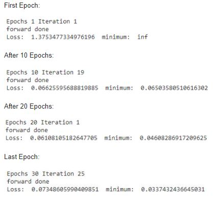

Decreasing learning rate improved the performance of the model, it does not diverge and bounce but we reach a relatively good value for the loss and for the comparison between the predicted mask and the ground truth improved as well.

Average dice score: 0.9214476249649843.

**The next experiment tested a learning rate of 0.0001:**

Result:

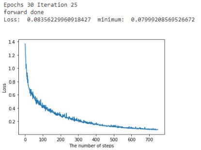

# Tuning SGD's hyperparameters

**The following set of the experiments were executed using the cross entropy loss and the SGD optimizer with tuned hyperparameters to see if we could get better results:**

**Learning rate**

Loss = nn.CrossEntropyLoss() optimizer = torch.optim.SGD(model.parameters(), lr=0.001, momentum=0.99)

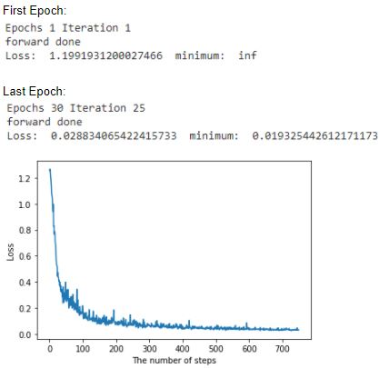

Average dice score: 0.9685934682137077.

# Conclusion:

Throughout this process we learned that there were ways for improvement even when the model performed well compared to lower scores. By conducting individual experiments we could establish which changes were responsible for lower or higher scores and see how adjusting these variables affected the way the model was trained. However, despite all the changes made to the hyperparameters there was a limit on how well the model could be trained and tested to produce good scores and so revisiting the structure of the model proved to be incredibly useful. The best performance was achieved by implementing an appropriate U-Net architecture that fit the data for the model and then using a combination of the cross entropy loss with the Adam optimiser. This, once tested multiple times on a range of hyperparameters and over a number of epochs produced the best reliable results and resulted in dice scores that were much higher than the initial scores we received.

# References

https://www.jeremyjordan.me/semantic-segmentation/

https://lmb.informatik.uni-freiburg.de/people/ronneber/u-net/

https://towardsdatascience.com/understanding-semantic-segmentation-with-unet-6be4f42d4b47

https://en.wikipedia.org/wiki/U-Net

# Bibliography

[1] https://lmb.informatik.uni-freiburg.de/people/ronneber/u-net/

[2] https://towardsdatascience.com/unet-line-by-line-explanation-9b191c76baf5